# Proyecto 1. Análisis Exploratorio

Andre Jo

2025-01-31

## Leer CSV Movies y realizar importaciones de librerias externas

```r
library(ggplot2)
datos <- read.csv("movies.csv")
```

## 4.7. (8 puntos) ¿Las películas de qué genero principal obtuvieron mayores ganancias?

```r
datos_br <- datos[, c("genres", "budget", "revenue")]
profit <- cbind(datos_br, profit=datos$revenue-datos$budget)

#Quitar los ceros y generos en espacios blancos
profit <- profit[apply(profit!=0, 1, all), ]
profit <- profit[apply(profit!='', 1, all), ]
#Sacar el genero principal de la pelicula
genre_main = c()
for (genre in profit$genres) {
  main_genre <- strsplit(x=genre,split="|", fixed = TRUE)[[1]][1]
  genre_main <- append(genre_main, main_genre)
}
da <- cbind(genre_main, profit)
da <- aggregate(da$profit, list(da$genre_main), FUN=mean)
colnames(da) <- c("Generos", "Ganancia")
pregunta4.7 <- da[order(da$Ganancia, decreasing = TRUE), ]

head(pregunta4.7)
```

```
##            Generos  Ganancia
## 2        Adventure 173915372
## 3        Animation 173682706
## 8           Family 137238663
## 15 Science Fiction 120688751
## 1           Action 119572299
## 9          Fantasy 113629994
```

Se afirma que los generos que más ganancias obtuvieron fueron los siguientes: Adventure, Animation, Family, Science Fiction, Action y Fantasy con una ganancia mayor a 100,000,000

### 4.8 ¿La cantidad de actores influye en los ingresos de las películas? ¿se han hecho películas con más actores en los últimos años?

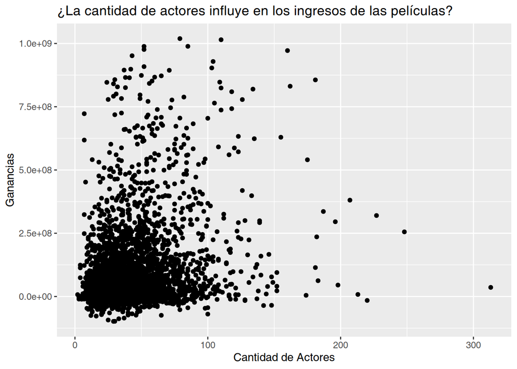

```r
datos_br <- datos[, c( "title", "budget", "revenue", "actorsAmount")]
datos_br <- datos_br[apply(datos_br!=0, 1,all),]
datos_br <- datos_br[order(datos_br$actorsAmount, decreasing = TRUE), ]
profit <- cbind(datos_br, profit=datos_br$revenue-datos_br$budget)
a_graficar <- profit[ , c("profit", "actorsAmount") ]
a_graficar <- a_graficar[apply(a_graficar!=565916, 1,all),]
a_graficar <- a_graficar[apply(a_graficar!=0, 1,all),]
# Plot
ggplot(a_graficar, aes(x=actorsAmount, y=profit)) + geom_point() +
labs(title = "¿La cantidad de actores influye en los ingresos de las películas?", x = "Cantidad de Actores", y = "Ganancias") +
ylim(-102566092, 1022566902)
```

No, como se observa en la gráfica hay solo hay una concentración en el rango de 100 actores donde se observa que las ganancias pueden alcanzar a 1022566902 mientras que cantidades en el rango de 200 y 300 no se esperan tantas ganancias.

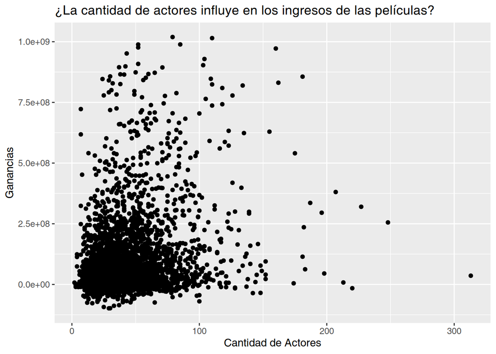

```r
datos_br <- datos[, c( "title", "budget", "revenue", "actorsAmount")]
datos_br <- datos_br[apply(datos_br!=0, 1,all),]
datos_br <- datos_br[order(datos_br$actorsAmount, decreasing = TRUE), ]
profit <- cbind(datos_br, profit=datos_br$revenue-datos_br$budget)
a_graficar <- profit[ , c("profit", "actorsAmount") ]
a_graficar <- a_graficar[apply(a_graficar!=565916, 1,all),]
a_graficar <- a_graficar[apply(a_graficar!=0, 1,all),]
# Plot
ggplot(a_graficar, aes(x=actorsAmount, y=profit)) + geom_point() +
labs(title = "¿La cantidad de actores influye en los ingresos de las películas?", x = "Cantidad de Actores", y = "Ganancias") +
ylim(-102566092, 1022566902)
```

```r
datos_br <- datos[, c( "title", "releaseDate", "actorsAmount")]
datos_br <- datos_br[order(datos_br$releaseDate, decreasing = TRUE), ]

anios <- format(as.Date(datos_br$releaseDate), "%Y")

pregunta4.8 <- cbind( datos_br, anios)
pregunta4.8 <-aggregate(pregunta4.8$actorsAmount, by = list(Anios = pregunta4.8$anios), FUN=sum)
pregunta4.8 <- pregunta4.8[order(pregunta4.8$x, decreasing = TRUE), ]
```

##4.9. (3 puntos) ¿Es posible que la cantidad de hombres y mujeres en el reparto influya en la popularidad y los ingresos de las películas?

```r
## 4.9. (3 puntos) ¿Es posible que la cantidad de hombres y mujeres en el reparto influya en la popularidad y los ingresos de las películas?

pregunta4.9 <- datos[ , c( "castMenAmount", "castWomenAmount", "revenue", "popularity" ) ]

pregunta4.9 <- na.exclude(pregunta4.9)

#Por alguna razon alguien escribio strings en datos numericos esto solo los convierte las columnas a numericos
pregunta4.9$castMenAmount <- as.numeric(pregunta4.9$castMenAmount)
pregunta4.9$castWomenAmount <- as.numeric(pregunta4.9$castWomenAmount)
pregunta4.9 <- pregunta4.9[order(pregunta4.9$revenue, decreasing = TRUE), ]
pregunta4.9 <- pregunta4.9[apply(pregunta4.9[, c("castMenAmount", "castWomenAmount", "revenue")]!=0, 1, all), ]

head(pregunta4.9)
```

```
##      castMenAmount castWomenAmount    revenue popularity
## 3211            21               9 2847246203    558.792
## 5953            62              28 2797800564    422.152
## 308             59              27 2187463944    186.300
## 4948            74              24 2068223624    105.189
## 5954            43              21 2046239637    648.960
## 4915            31              13 1671713208    152.090
```

No afecta la cantidad de hombres y mujeres, ya que se observa que no existe una relación significativa entre la popularidad y los ingresos, dado que no hay una diferencia notable.

```r
pregunta4.10 <- datos[ 1:20 , c( "director", "voteAvg") ]
pregunta4.10 <- pregunta4.10[order(pregunta4.10$voteAvg, decreasing = TRUE), ]
head(pregunta4.10 )
```

```
##                director voteAvg
## 5       Robert Zemeckis     8.5
## 15 Francis Ford Coppola     8.3
## 3          George Lucas     8.2
## 10           Fritz Lang     8.2
## 18        Michel Gondry     8.1
## 6            Sam Mendes     8.0
```

## 4.11. (8 puntos) ¿Cómo se correlacionan los presupuestos con los ingresos? ¿Los altos presupuestos significan altos ingresos? Haga los gráficos que necesite, histograma, diagrama de dispersión

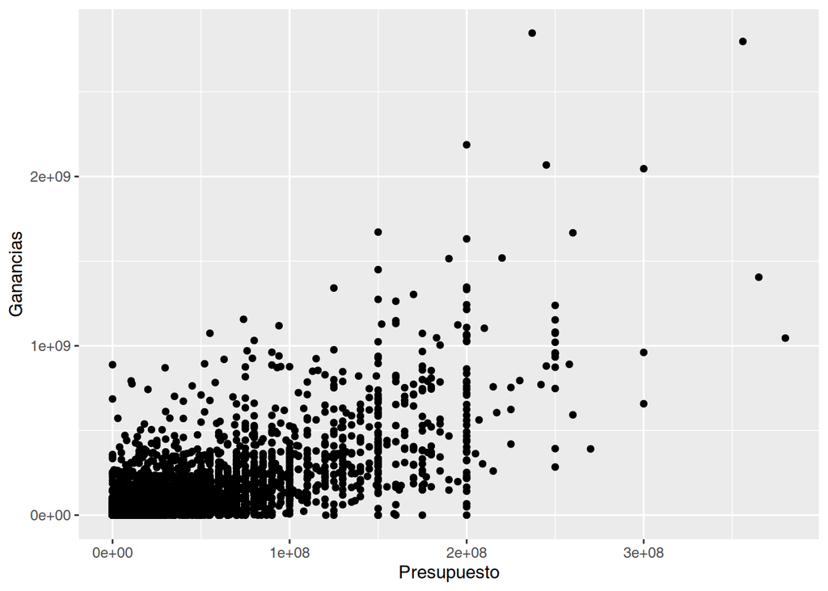

```r
pregunta4.11 <- datos[ , c( "revenue", "budget") ]
pregunta4.11 <- pregunta4.11[apply(pregunta4.10!=0, 1, all), ]
ggplot(pregunta4.11, aes(y=revenue, x=budget)) + geom_point() +
  labs(x = "Presupuesto", y = "Ganancias")
```

##4.12 ¿Se asocian ciertos meses de lanzamiento con mejores ingresos?

```r
pregunta4.12 <- datos[ , c( "releaseDate", "revenue") ]
#Quitar los revenues que tienen 0
pregunta4.12 <- pregunta4.12[apply(pregunta4.12!=0, 1, all), ]
meses <- format(as.Date(pregunta4.12$releaseDate), "%m")

pregunta4.12 <- cbind( pregunta4.12, meses)

pregunta4.12 <- aggregate(pregunta4.12$revenue, list(meses), FUN=mean)
colnames(pregunta4.12) <- c("Fecha Lanzamiento", "Ingresos")
head(pregunta4.12)
```

```
##   Fecha Lanzamiento  Ingresos
## 1                01  69465131
## 2                02  82995335
## 3                03  97108375
## 4                04 101968175
## 5                05 165272557
## 6                06 165807439
```

#4.13 ¿En qué meses se han visto los lanzamientos con mejores ingresos? ¿cuantas películas, en promedio, se han lanzado por mes?

```r
pregunta4.13 <- pregunta4.12[order(pregunta4.12$Ingresos, decreasing = TRUE), ]
pregunta4.13[ 1:4 ,]
```

```
##    Fecha Lanzamiento  Ingresos
## 6                 06 165807439
## 5                 05 165272557
## 11                11 140375024
## 12                12 135527394
```

```r
pregunta4.11 <- datos[ , c( "releaseDate", "revenue") ]
pregunta4.11 <- pregunta4.11[apply(pregunta4.11!=0, 1, all), ]
meses <- format(as.Date(pregunta4.11$releaseDate), "%m")
mese <- aggregate(pregunta4.11$revenue, list(meses), FUN=length)

mean(mese$x)
```

```
## [1] 435.25
```

##4.14. ¿Cómo se correlacionan las calificaciones con el éxito comercial?

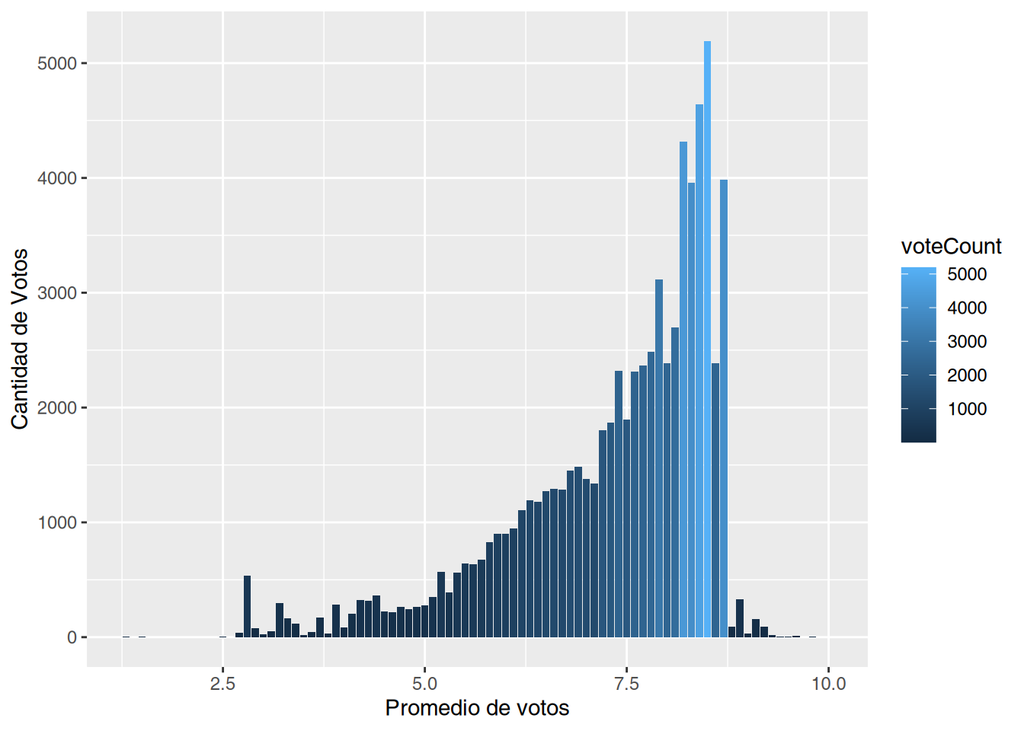

```r
pregunta4.14 <- datos[ , c( "voteAvg", "voteCount") ]

pregunta4.14 <- aggregate(pregunta4.14$voteCount, list(pregunta4.14$voteAvg), FUN=mean)
colnames(pregunta4.14) <- c("voteAvg", "voteCount")

ggplot(pregunta4.14, aes(y=voteCount, x=voteAvg, fill=voteCount)) + geom_bar(stat = "identity") +
  labs(y = "Cantidad de Votos", x = "Promedio de votos")
```

La relación entre las calificaciones y el éxito comercial en películas se infiere que calificaciones moderadamente altas (alrededor de 8) tienden a tener más éxito en términos de audiencia, con más de 5,000 personas otorgando esta puntuación. Esto sugiere que no siempre las películas mejor calificadas son las más exitosas comercialmente.

##15¿Qué estrategias de marketing, como videos promocionales o páginas oficiales, generan mejores resultados?

```r
pregunta4.15 <- datos[ , c( "homePage", "video", "voteCount") ]
pregunta4.15$homePage <- !is.na(pregunta4.15$homePage) & pregunta4.15$homePage != ""
pregunta4.15 <- pregunta4.15[order(-pregunta4.15$video), ]
pregunta4.15 <- aggregate(voteCount ~ video + homePage, data = pregunta4.15, FUN = sum)
head(pregunta4.15)
```

```
##   video homePage voteCount
## 1 FALSE    FALSE   4488605
## 2  TRUE    FALSE      5259
## 3 FALSE     TRUE   7150421
## 4  TRUE     TRUE      1911
```

Como se puede observar con la siguiente tabla, se observa que al no tener un video o tener una pagina de promoción se esperan mejores resultados. Mientras que peliculas que si tienen páginas web y videos no generan mejores resultados

## 16: ¿La popularidad del elenco está directamente correlacionada con el éxito de taquilla?

```r
pregunta4.16 <- datos[, c("actorsPopularity", "revenue")]
for (i in 1:nrow(pregunta4.16)) {
  for (j in 1:ncol(pregunta4.16)) {
    if (is.character(pregunta4.16[i, j])) {
      split_values <- strsplit(pregunta4.16[i, j], "\\|")[[1]]
      numeric_values <- as.numeric(split_values)
      mean_value <- mean(numeric_values, na.rm = TRUE)
      pregunta4.16[i, j] <- mean_value
    }
  }
}

pregunta4.16 <- pregunta4.16[order(pregunta4.16$revenue, decreasing = TRUE), ]
pregunta4.16 <- pregunta4.16[apply(pregunta4.16!="NaN", 1, all), ]
pregunta4.16 <- pregunta4.16[apply(pregunta4.16!=0, 1, all), ]
head(pregunta4.16)
```

```
##      actorsPopularity    revenue
## 3211  6.5532972972973 2847246203
## 5953 15.0504368932039 2797800564
## 308  3.27228448275862 2187463944
## 4948 4.10664361702128 2068223624
## 5954          17.2132 2046239637
## 4915        6.4104375 1671713208
```

[figure not shown]

```r
ggplot(pregunta4.16, aes(x = actorsPopularity, y = revenue)) +
  geom_point() +
  labs( x = "actorsPopularity", y = "revenue")
```

Se observa en la gráfica que la popularidad del actor no afecta con el éxito comercial de la taquilla en la cual es generar mayor cantidad de ingresos.

##EXTRAS Genere usted otras seis preguntas que le parezcan interesantes porque le permitan realizar otras exploraciones y respóndalas. No puede repetir ninguna de las instrucciones anteriores.

#4. ¿Existe una correlación entre el número de compañías productoras involucradas en una película y su presupuesto total?

```r
company_x_budget  <- datos[, c("productionCoAmount" , "budget")]
company_x_budget <- company_x_budget[order(company_x_budget$productionCoAmount, decreasing = TRUE), ]
company_x_budget <- company_x_budget[apply(company_x_budget!=0, 1, all), ]
company_x_budget <- aggregate(company_x_budget$budget, list(company_x_budget$productionCoAmount), FUN=mean)
colnames(company_x_budget) <- c("productionCoAmount", "budget")
company_x_budget
```

```
##    productionCoAmount   budget
## 1                   1 26329368
## 2                   2 33015173
## 3                   3 32565605
## 4                   4 41083853
## 5                   5 42605936
## 6                   6 47807805
## 7                   7 44336738
## 8                   8 43657015
## 9                   9 31155699
## 10                 10 48378894
## 11                 11 37371236
## 12                 12 36015753
## 13                 13 20635184
## 14                 14  8013982
## 15                 15 21969880
## 16                 16 31136576
## 17                 17  4233333
## 18                 18 29007434
## 19                 19 24950000
## 20                 20  7433333
## 21                 21 10000000
## 22                 22  6750000
## 23                 26 12800000
## 24                 89 10000000
```

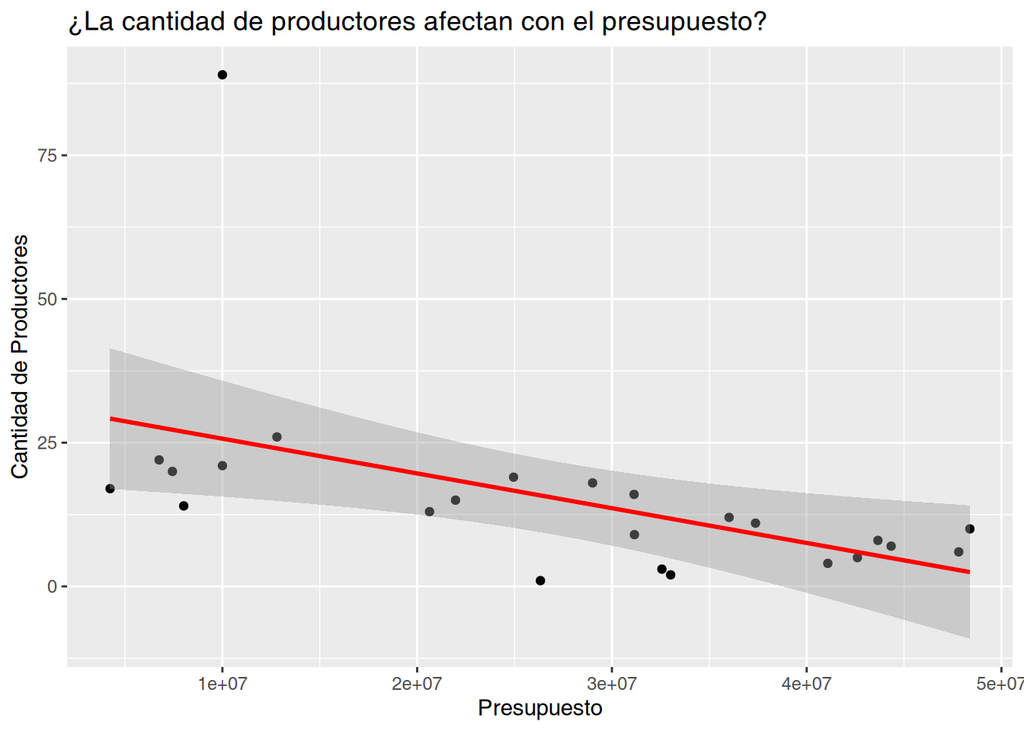

```r
ggplot(company_x_budget, aes(y=productionCoAmount, x=budget)) +   geom_point() +
  geom_smooth(method = "lm", col = "red") +
 labs(title = "¿La cantidad de productores afectan con el presupuesto?", x = "Presupuesto", y = "Cantidad de Productores")
```

Aunque se ve un punto atípico y con la cantidad de actores; se observa que entre mas compañias estan presentes, su presupuestos tiende a bajar como se muestra en esta linea de tendencia.

#5. El lenguaje afecta con el exito comercial ya que genera una mayor cantidad de ingresos?

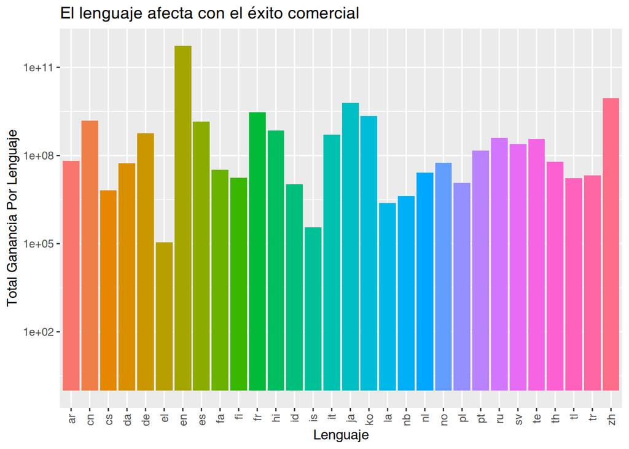

```r
lenguaje <- datos[, c("originalLanguage", "revenue")]
lenguaje <- aggregate(lenguaje$revenue, list(lenguaje$originalLanguage), FUN=sum)
colnames(lenguaje) <- c("Lenguaje", "Total_Ganancia_Por_Lenguaje")
lenguaje <- lenguaje[apply(lenguaje!=0, 1, all), ]
ggplot(lenguaje, aes(x=Lenguaje, y=Total_Ganancia_Por_Lenguaje, fill=Lenguaje)) +
  geom_bar(stat="identity") +
  labs(title = "El lenguaje afecta con el éxito comercial",
       x = "Lenguaje",
       y = "Total Ganancia Por Lenguaje") +
  theme(axis.text.x = element_text(angle = 90, vjust = 0.5, hjust=1)) +
  theme(legend.position = "none") +
  scale_y_log10()
```

El idioma que ha generado mayores ingresos en las peliculas es el inglés, seguido por el chino en segundo lugar y el japonés en tercero. Esto se debe a que una gran parte de la población hablan el inglés o tiene una preferencia por ver y escuchar películas en este idioma, lo que contribuye a su éxito comercial.

##6.Que país es el más utilizado para producir una pelicula?

```r
paises <- datos$productionCountry
paises_list <- strsplit(paises, split = "\\|", fixed = FALSE)
todos_paises <- unlist(paises_list)
todos_paises <- todos_paises[!is.na(todos_paises) & todos_paises != ""]
all_pais <- as.data.frame(table(todos_paises), stringsAsFactors = FALSE)
colnames(all_pais) <- c("Pais", "Total")
all_pais <- all_pais[apply(all_pais!=0, 1, all), ]
head(all_pais)
```

```
##          Pais Total
## 1 Afghanistan     1
## 2     Albania     2
## 3     Algeria     1
## 4      Angola     1
## 5  Antarctica     1
## 6   Argentina    70
```

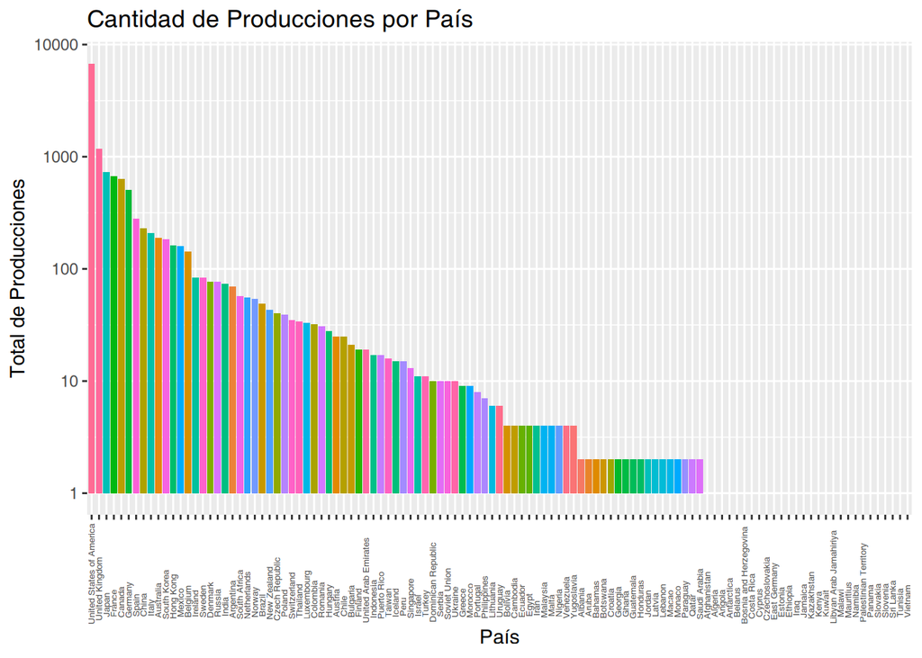

```r
ggplot(all_pais, aes(x = reorder(Pais, -Total), y = Total, fill = Pais)) +
  geom_bar(stat = "identity") +
  labs(title = "Cantidad de Producciones por País",
       x = "País",
       y = "Total de Producciones") +
  theme(axis.text.x = element_text(angle = 90, vjust = 0.5, hjust = 0.1, size = 5)) +
  theme(legend.position = "none") +   scale_y_log10()
```

Se observa que los países con mayor producción cinematográfica son Estados Unidos, Reino Unido y Japón.